##### Scatterplot

To visualize the dependence between two variables, a scatterplot should be the first choice.

The following example illustrates the dependence between plant richness and elevation using the `plot()` function.

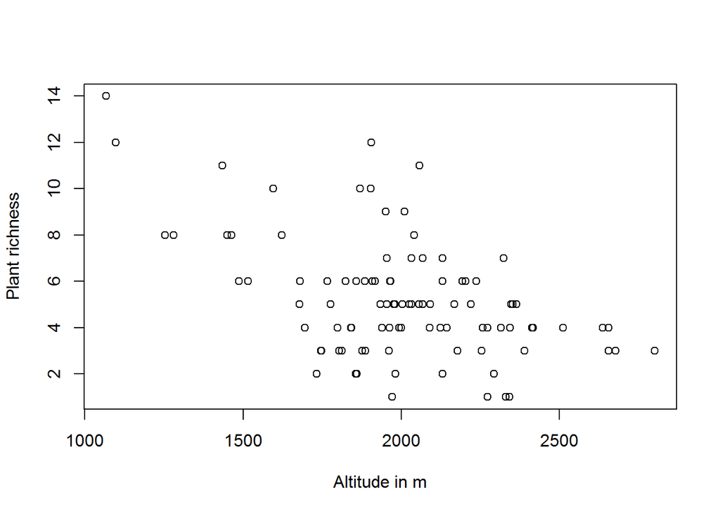

```r
plot(data_2007$ALT_GPS_M, richness,xlab="Altitude in m",ylab="Plant richness")
```

Although not a hard one, some kind of linear relationship can be observed with decreasing plant richness with altitude.

#### Computation

To model the relationship between two linearily related variables, a simple linear regression can be used.

The following example illustrates the computation of a linear model between plant richness and elevation.

```r
linear_model <- lm(richness ~ data_2007$ALT_GPS_M)
print(linear_model)
```

```
##
## Call:
## lm(formula = richness ~ data_2007$ALT_GPS_M)
##
## Coefficients:
##         (Intercept)  data_2007$ALT_GPS_M
##            13.10981             -0.00396
```

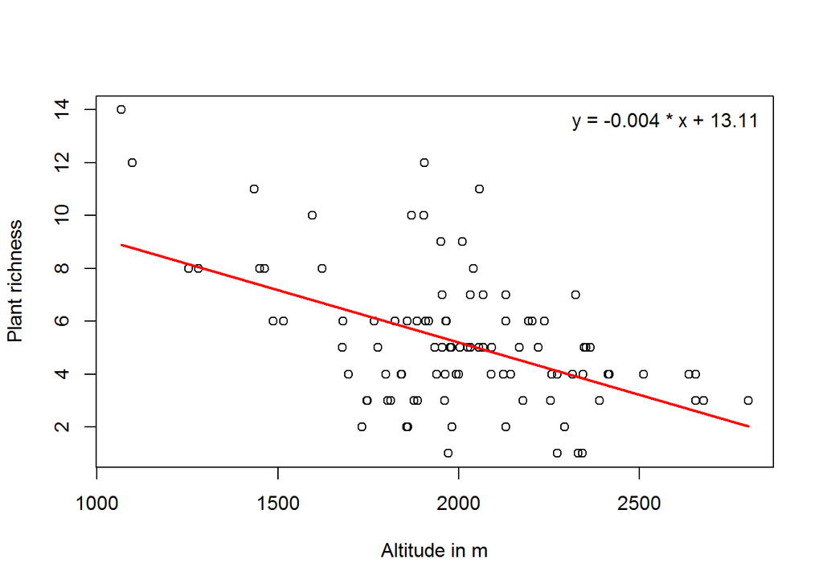

```r
plot(data_2007$ALT_GPS_M, richness,xlab="Altitude in m",ylab="Plant richness")
regLine(linear_model)
legend("topright",legend=paste0("y = ", round(linear_model$coefficients[2],3),
                                " * x + ",
                                round(linear_model$coefficients[1],3)),bty="n")
```

#### Goodness of fit

To estimate the goodness of fit of a linear model, one can have a look at the coefficient of determination along with the p-value.

```r
summary(linear_model)
```

```
##
## Call:
## lm(formula = richness ~ data_2007$ALT_GPS_M)
##
## Residuals:
##    Min     1Q Median     3Q    Max
##  -4.30  -1.45  -0.04   1.23   6.44
##
## Coefficients:
##                      Estimate Std. Error t value Pr(>|t|)
## (Intercept)         13.109812   1.448783    9.05  1.5e-14 ***
## data_2007$ALT_GPS_M -0.003961   0.000716   -5.53  2.7e-07 ***
## ---
## Signif. codes:  0 '***' 0.001 '**' 0.01 '*' 0.05 '.' 0.1 ' ' 1
##
## Residual standard error: 2.3 on 97 degrees of freedom
## Multiple R-squared:  0.24,   Adjusted R-squared:  0.232
## F-statistic: 30.6 on 1 and 97 DF,  p-value: 2.72e-07
```

One can see from the summary, that the model is highly significant with a p-value of much less than 0.01. Looking at an r squared of about 0.23, the model explains about 23% of the variability of the data set, i.e. one can explain 23% of the observed plant richness by the elevation of the observational plots.